# data_and_modeling

# 1. Naive approach

```python
na_df=df_weather.copy()
na_df.head()
```

|  | Date | Hour | Consumption | T_1 | T_2 | T_3 | T_4 | T_5 | T_6 | T_7 | Datetime |
| --- | --- | --- | --- | --- | --- | --- | --- | --- | --- | --- | --- |
| 0 | 2017-01-01 | 00:00:00 | 25409.3134 | -15.88 | 4.18 | 0.89 | -18.96 | -14.77 | -10.68 | 2.16 | 2017-01-01 00:00:00 |
| 1 | 2017-01-01 | 01:00:00 | 24166.1420 | -15.88 | 4.18 | 0.89 | -18.96 | -14.77 | -10.68 | 2.16 | 2017-01-01 01:00:00 |
| 2 | 2017-01-01 | 02:00:00 | 22652.0209 | -15.88 | 4.18 | 0.89 | -18.96 | -14.77 | -10.68 | 2.16 | 2017-01-01 02:00:00 |
| 3 | 2017-01-01 | 03:00:00 | 21578.0522 | -15.88 | 4.18 | 0.89 | -18.96 | -14.77 | -10.68 | 2.16 | 2017-01-01 03:00:00 |
| 4 | 2017-01-01 | 04:00:00 | 21018.1962 | -15.88 | 4.18 | 0.89 | -18.96 | -14.77 | -10.68 | 2.16 | 2017-01-01 04:00:00 |

```python
na_df["naive_day"]=na_df["Consumption"].shift(24*2)
na_df["naive_week"]=na_df["Consumption"].shift(24*7)
na_df["naive_year"]=na_df["Consumption"].shift(24*365)
na_df=na_df.dropna().reset_index(drop=True)
```

```python
from sklearn.metrics import mean_absolute_error,mean_squared_error

print("MAE for day lag: ", mean_absolute_error(na_df["Consumption"],na_df["naive_day"]))
print("MAE for week lag: ", mean_absolute_error(na_df["Consumption"],na_df["naive_week"]))
print("MAE for year lag: ", mean_absolute_error(na_df["Consumption"],na_df["naive_year"]))

print()

print("MSE for day lag: ", mean_squared_error(na_df["Consumption"],na_df["naive_day"]))
print("MSE for week lag: ", mean_squared_error(na_df["Consumption"],na_df["naive_week"]))
print("MSE for year lag: ", mean_squared_error(na_df["Consumption"],na_df["naive_year"]))
```

```
MAE for day lag:  2481.1140645604396
MAE for week lag:  1537.6846649725273
MAE for year lag:  2589.964445392628

MSE for day lag:  12466218.147057965
MSE for week lag:  7286732.979018596
MSE for year lag:  13338482.90975774
```

# 2. Moving average

We will simply take the mean of the last 24 hours data to predict the next hour.

- Pros:
  - Lower computation.
  - Good for business decision which does not require much precision.
- Cons
  - Lower precision
  - There will still be unexplained variance.
  - The seasonality attribute of the data is not explained.

```python
ma_df=df_weather.copy()
ma_df=ma_df[["Datetime","Consumption"]]
ma_df.head()
```

|  | Datetime | Consumption |
| --- | --- | --- |
| 0 | 2017-01-01 00:00:00 | 25409.3134 |
| 1 | 2017-01-01 01:00:00 | 24166.1420 |
| 2 | 2017-01-01 02:00:00 | 22652.0209 |
| 3 | 2017-01-01 03:00:00 | 21578.0522 |
| 4 | 2017-01-01 04:00:00 | 21018.1962 |

```python
ma_df["Log_Consumption"]=np.log(ma_df["Consumption"])
ma_df["MA_Log"]=ma_df[["Datetime","Log_Consumption"]].rolling(24).mean().values
ma_df["MA_Log"]=np.exp(ma_df["MA_Log"])
ma_df=ma_df.dropna().reset_index(drop=True)
ma_df.head()
```

[output not shown]

```python
print("MAE for logarithmic MA: ", mean_absolute_error(ma_df["Consumption"],ma_df["MA_Log"]))
print("MAE for normal MA: ", mean_absolute_error(ma_df["Consumption"],ma_df["MA_Normal"]))
print()
print("MSE for logarithmic MA: ", mean_squared_error(ma_df["Consumption"],ma_df["MA_Log"]))
print("MSE for normal MA: ", mean_squared_error(ma_df["Consumption"],ma_df["MA_Normal"]))
```

```
MAE for logarithmic MA:  3315.4809242318925
MAE for normal MA:  3277.847130343259

MSE for logarithmic MA:  15010159.261606853
MSE for normal MA:  14952336.77938222
```

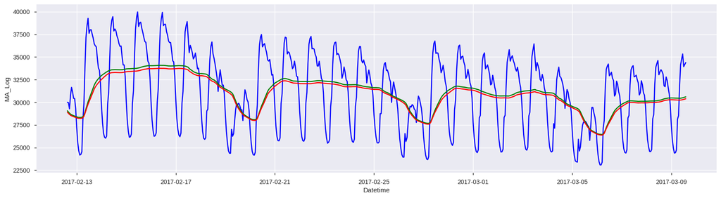

```python
plt.figure(figsize=(20,5))
sns.lineplot(x="Datetime",y="Consumption",data=ma_df[["Datetime","Consumption"]].iloc[1000:1600],color="blue")
sns.lineplot(x="Datetime",y="MA_Normal",data=ma_df[["Datetime","MA_Normal"]].iloc[1000:1600],color="green")
sns.lineplot(x="Datetime",y="MA_Log",data=ma_df[["Datetime","MA_Log"]].iloc[1000:1600],color="red")
```

# 2. SARIMA

- p: The number of lag observations included in the model, also called the lag order.
- d: The number of times that the raw observations are differenced, also called the degree of differencing.
- q: The size of the moving average window, also called the order of moving average.

```python
arima_df=df_weather.copy()
```

```python
arima_df
```

|  | Date | Hour | Consumption | T_1 | T_2 | T_3 | T_4 | T_5 | T_6 | T_7 | Datetime |
| --- | --- | --- | --- | --- | --- | --- | --- | --- | --- | --- | --- |
| 0 | 2017-01-01 | 00:00:00 | 25409.3134 | -15.88 | 4.18 | 0.89 | -18.96 | -14.77 | -10.68 | 2.16 | 2017-01-01 00:00:00 |
| 1 | 2017-01-01 | 01:00:00 | 24166.1420 | -15.88 | 4.18 | 0.89 | -18.96 | -14.77 | -10.68 | 2.16 | 2017-01-01 01:00:00 |
| 2 | 2017-01-01 | 02:00:00 | 22652.0209 | -15.88 | 4.18 | 0.89 | -18.96 | -14.77 | -10.68 | 2.16 | 2017-01-01 02:00:00 |
| 3 | 2017-01-01 | 03:00:00 | 21578.0522 | -15.88 | 4.18 | 0.89 | -18.96 | -14.77 | -10.68 | 2.16 | 2017-01-01 03:00:00 |
| 4 | 2017-01-01 | 04:00:00 | 21018.1962 | -15.88 | 4.18 | 0.89 | -18.96 | -14.77 | -10.68 | 2.16 | 2017-01-01 04:00:00 |
| ... | ... | ... | ... | ... | ... | ... | ... | ... | ... | ... | ... |
| 26227 | 2019-12-29 | 19:00:00 | 36326.3600 | 0.64 | 9.23 | 6.01 | 0.43 | -0.51 | 0.34 | 6.06 | 2019-12-29 19:00:00 |
| 26228 | 2019-12-29 | 20:00:00 | 35622.9000 | 0.80 | 8.94 | 5.85 | 0.32 | -0.80 | -0.30 | 6.09 | 2019-12-29 20:00:00 |
| 26229 | 2019-12-29 | 21:00:00 | 34922.9500 | 0.97 | 8.65 | 5.70 | 0.21 | -1.08 | -0.93 | 6.13 | 2019-12-29 21:00:00 |
| 26230 | 2019-12-29 | 22:00:00 | 33850.4800 | 0.80 | 8.75 | 5.61 | 0.25 | -1.14 | -0.90 | 6.40 | 2019-12-29 22:00:00 |
| 26231 | 2019-12-29 | 23:00:00 | 32683.5900 | 0.63 | 8.86 | 5.52 | 0.30 | -1.20 | -0.87 | 6.67 | 2019-12-29 23:00:00 |

26232 rows × 11 columns

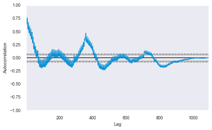

```python
from pandas.plotting import autocorrelation_plot

autocorrelation_plot(arima_df.loc[arima_df["Hour"]=="0{}:00:00".format(1)]["Consumption"])
```

When we take a look at the we still see the seasonality which probabilty caused by the weeks or months. From here on I concluded that ARIMA would only be waste of time so I tried SARIMA, which is the seasonal model of the ARIMA model.

```python
import statsmodels.api as sm
mod = sm.tsa.statespace.SARIMAX(arima_df["Consumption"],
                                order=(1, 0, 1),
                                seasonal_order=(1, 1, 1, 6))
results = mod.fit()
print(results.summary().tables[1])
# cok uzun suruyor
```

```
==============================================================================
                 coef    std err          z      P>|z|      [0.025      0.975]
------------------------------------------------------------------------------
ar.L1          1.0000      0.001   1737.739      0.000       0.999       1.001
ma.L1          0.6106      0.005    125.940      0.000       0.601       0.620
ar.S.L6       -0.2601      0.005    -48.456      0.000      -0.271      -0.250
ma.S.L6       -0.9999      0.000  -4703.139      0.000      -1.000      -0.999
sigma2      1.032e+06   1.12e-09   9.22e+14      0.000    1.03e+06    1.03e+06
==============================================================================
```

[figure not shown]

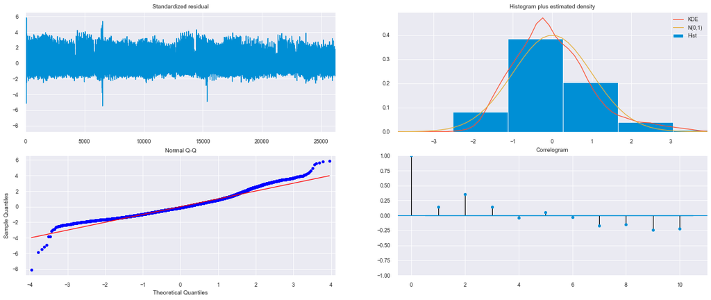

```python
results.plot_diagnostics(figsize=(18, 8))
```

```python
arima_df
```

|  | Date | Hour | Consumption | T_1 | T_2 | T_3 | T_4 | T_5 | T_6 | T_7 | Datetime |
| --- | --- | --- | --- | --- | --- | --- | --- | --- | --- | --- | --- |
| 0 | 2017-01-01 | 00:00:00 | 25409.3134 | -15.88 | 4.18 | 0.89 | -18.96 | -14.77 | -10.68 | 2.16 | 2017-01-01 00:00:00 |
| 1 | 2017-01-01 | 01:00:00 | 24166.1420 | -15.88 | 4.18 | 0.89 | -18.96 | -14.77 | -10.68 | 2.16 | 2017-01-01 01:00:00 |
| 2 | 2017-01-01 | 02:00:00 | 22652.0209 | -15.88 | 4.18 | 0.89 | -18.96 | -14.77 | -10.68 | 2.16 | 2017-01-01 02:00:00 |
| 3 | 2017-01-01 | 03:00:00 | 21578.0522 | -15.88 | 4.18 | 0.89 | -18.96 | -14.77 | -10.68 | 2.16 | 2017-01-01 03:00:00 |
| 4 | 2017-01-01 | 04:00:00 | 21018.1962 | -15.88 | 4.18 | 0.89 | -18.96 | -14.77 | -10.68 | 2.16 | 2017-01-01 04:00:00 |
| ... | ... | ... | ... | ... | ... | ... | ... | ... | ... | ... | ... |
| 26227 | 2019-12-29 | 19:00:00 | 36326.3600 | 0.64 | 9.23 | 6.01 | 0.43 | -0.51 | 0.34 | 6.06 | 2019-12-29 19:00:00 |
| 26228 | 2019-12-29 | 20:00:00 | 35622.9000 | 0.80 | 8.94 | 5.85 | 0.32 | -0.80 | -0.30 | 6.09 | 2019-12-29 20:00:00 |
| 26229 | 2019-12-29 | 21:00:00 | 34922.9500 | 0.97 | 8.65 | 5.70 | 0.21 | -1.08 | -0.93 | 6.13 | 2019-12-29 21:00:00 |
| 26230 | 2019-12-29 | 22:00:00 | 33850.4800 | 0.80 | 8.75 | 5.61 | 0.25 | -1.14 | -0.90 | 6.40 | 2019-12-29 22:00:00 |
| 26231 | 2019-12-29 | 23:00:00 | 32683.5900 | 0.63 | 8.86 | 5.52 | 0.30 | -1.20 | -0.87 | 6.67 | 2019-12-29 23:00:00 |

26232 rows × 11 columns

### So, here I will create two manipulated dataframes :

1. will have lag comsumptions of exactly (hourwise) 2 days before, 7 days before and 365 days before.
2. the other dataframe will have the comsumption like the first dataframe but will have all the hours in the subject day.

Here our data will shrink a little however we will be able to create a model that understands the seasonality.

Also, we will have the opportunity to use the other variables, which we were unable to.

### Then, I will perform different regression algorithms.

```python
df_first=df_weather.copy()
df_first["lag_two_day"]=df_first["Consumption"].shift(24*2)
df_first["lag_week"]=df_first["Consumption"].shift(24*7)
df_first["lag_year"]=df_first["Consumption"].shift(24*365)
for temps in ["T_1","T_2","T_3","T_4","T_5","T_6","T_7"]:
    df_first["previous_"+temps]=df_first[temps].shift(48)

df_first=df_first.dropna().reset_index(drop=True)
df_first.head()
```

|  | Date | Hour | Consumption | T_1 | T_2 | T_3 | T_4 | T_5 | T_6 | T_7 | ... | lag_two_day | lag_week | lag_year | previous_T_1 | previous_T_2 | previous_T_3 | previous_T_4 | previous_T_5 | previous_T_6 | previous_T_7 |
| --- | --- | --- | --- | --- | --- | --- | --- | --- | --- | --- | --- | --- | --- | --- | --- | --- | --- | --- | --- | --- | --- |
| 0 | 2018-01-01 | 00:00:00 | 25404.9788 | 0.57 | 10.35 | 6.71 | 2.52 | -0.19 | 0.92 | 8.15 | ... | 29659.7202 | 28129.2327 | 25409.3134 | 2.10 | 13.22 | 9.97 | 2.19 | 5.58 | 3.74 | 12.22 |
| 1 | 2018-01-01 | 01:00:00 | 24235.7264 | 0.17 | 10.06 | 6.47 | 1.96 | -0.21 | 0.58 | 8.23 | ... | 27631.0334 | 26202.1853 | 24166.1420 | 2.08 | 13.27 | 9.81 | 2.00 | 5.43 | 3.68 | 12.10 |
| 2 | 2018-01-01 | 02:00:00 | 22885.4141 | -0.24 | 9.77 | 6.24 | 1.41 | -0.23 | 0.24 | 8.32 | ... | 26272.3917 | 25117.7345 | 22652.0209 | 2.05 | 13.31 | 9.66 | 1.82 | 5.27 | 3.62 | 11.98 |
| 3 | 2018-01-01 | 03:00:00 | 21931.9002 | -0.64 | 9.48 | 6.00 | 0.85 | -0.25 | -0.10 | 8.40 | ... | 25412.3874 | 24563.0727 | 21578.0522 | 2.03 | 13.36 | 9.50 | 1.63 | 5.12 | 3.56 | 11.86 |
| 4 | 2018-01-01 | 04:00:00 | 21516.5643 | -1.02 | 9.28 | 5.81 | 0.58 | -0.34 | -0.17 | 8.35 | ... | 25150.5101 | 24517.2447 | 21018.1962 | 2.00 | 13.33 | 9.58 | 1.46 | 5.04 | 3.45 | 11.67 |

5 rows × 21 columns

```python
df_second=df_weather.copy()

# hour lagging
for hour in range(24):
    df_second["two_day_{}hour_lag".format(hour)]=df_second["Consumption"].shift(24*2-hour)

# week lagging
for hour in range(24):
    df_second["week_{}hour_lag".format(hour)]=df_second["Consumption"].shift(24*7-hour)

# year lagging
for hour in range(24):
    df_second["year_{}hour_lag".format(hour)]=df_second["Consumption"].shift(24*365-hour)

for temps in ["T_1","T_2","T_3","T_4","T_5","T_6","T_7"]:
    df_second["previous_"+temps]=df_second[temps].shift(48)
df_second=df_second.dropna().reset_index(drop=True)
df_second.head()
```

|  | Date | Hour | Consumption | T_1 | T_2 | T_3 | T_4 | T_5 | T_6 | T_7 | ... | year_21hour_lag | year_22hour_lag | year_23hour_lag | previous_T_1 | previous_T_2 | previous_T_3 | previous_T_4 | previous_T_5 | previous_T_6 | previous_T_7 |
| --- | --- | --- | --- | --- | --- | --- | --- | --- | --- | --- | --- | --- | --- | --- | --- | --- | --- | --- | --- | --- | --- |
| 0 | 2018-01-01 | 00:00:00 | 25404.9788 | 0.57 | 10.35 | 6.71 | 2.52 | -0.19 | 0.92 | 8.15 | ... | 29378.1104 | 28922.0030 | 27561.2206 | 2.10 | 13.22 | 9.97 | 2.19 | 5.58 | 3.74 | 12.22 |
| 1 | 2018-01-01 | 01:00:00 | 24235.7264 | 0.17 | 10.06 | 6.47 | 1.96 | -0.21 | 0.58 | 8.23 | ... | 28922.0030 | 27561.2206 | 25453.1551 | 2.08 | 13.27 | 9.81 | 2.00 | 5.43 | 3.68 | 12.10 |
| 2 | 2018-01-01 | 02:00:00 | 22885.4141 | -0.24 | 9.77 | 6.24 | 1.41 | -0.23 | 0.24 | 8.32 | ... | 27561.2206 | 25453.1551 | 23992.4105 | 2.05 | 13.31 | 9.66 | 1.82 | 5.27 | 3.62 | 11.98 |
| 3 | 2018-01-01 | 03:00:00 | 21931.9002 | -0.64 | 9.48 | 6.00 | 0.85 | -0.25 | -0.10 | 8.40 | ... | 25453.1551 | 23992.4105 | 22939.2221 | 2.03 | 13.36 | 9.50 | 1.63 | 5.12 | 3.56 | 11.86 |
| 4 | 2018-01-01 | 04:00:00 | 21516.5643 | -1.02 | 9.28 | 5.81 | 0.58 | -0.34 | -0.17 | 8.35 | ... | 23992.4105 | 22939.2221 | 22603.8757 | 2.00 | 13.33 | 9.58 | 1.46 | 5.04 | 3.45 | 11.67 |

5 rows × 90 columns

## Playing on the real data's features:

```python
del df_first["Date"],df_first["Hour"],df_second["Date"],df_second["Hour"]
```

```python
# tbd: to be dropped demek cok kullanıcam
columns_tbd=["T_1","T_2","T_3","T_4","T_5","T_6","T_7"]
df_first["day"]=df_first["Datetime"].apply(lambda x: x.day)
df_first["month"]=df_first["Datetime"].apply(lambda x: x.month)
df_first["year"]=df_first["Datetime"].apply(lambda x: x.year)
df_first["weekday"]=df_first["Datetime"].apply(lambda x: x.weekday())
df_first["hour"]=df_first["Datetime"].apply(lambda x: x.hour)

df_first.drop(columns=columns_tbd,inplace=True)
df_first=df_first.set_index("Datetime")

df_second["day"]=df_second["Datetime"].apply(lambda x: x.day)
df_second["month"]=df_second["Datetime"].apply(lambda x: x.month)
df_second["year"]=df_second["Datetime"].apply(lambda x: x.year)
df_second["weekday"]=df_second["Datetime"].apply(lambda x: x.weekday())
df_second["hour"]=df_second["Datetime"].apply(lambda x: x.hour)

df_second.drop(columns=columns_tbd,inplace=True)
df_second=df_second.set_index("Datetime")
```

```python
df_first_cat,df_sec_cat=df_first.copy(),df_second.copy()
categoric_vars=["day","month","year","weekday","hour"]
```

# 4. Linear Regression

#### The first dataframe

```python
from sklearn.linear_model import LinearRegression
from sklearn.preprocessing import OneHotEncoder
from sklearn.model_selection import train_test_split
from scipy.sparse import hstack

enc_first=OneHotEncoder()
transformed_first=enc_first.fit_transform(df_first[categoric_vars])
label=df_first["Consumption"].values
del df_first["Consumption"]

df_first=hstack([df_first[df_first.columns.difference(categoric_vars)],transformed_first])
# train test split yapıcam ama date olarak ayırmak daha mantıklı cunku her bir instance unique

model_first=LinearRegression()
model_first.fit(df_first,label)
```

```
LinearRegression(copy_X=True, fit_intercept=True, n_jobs=None, normalize=False)
```

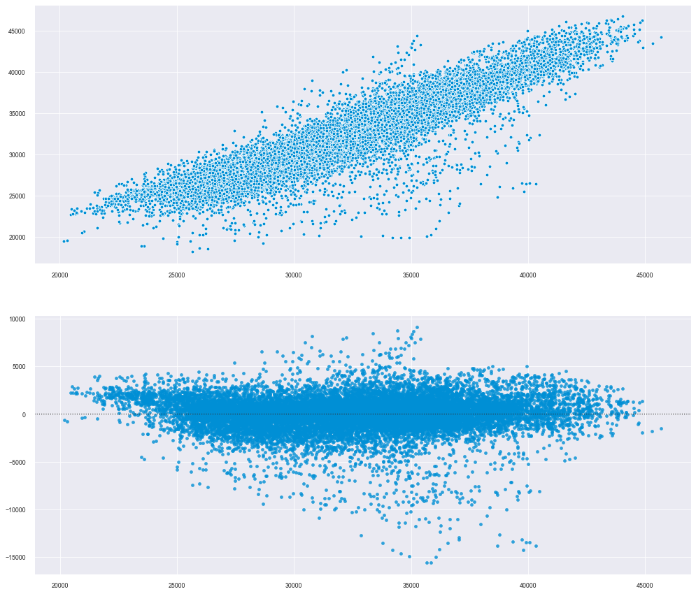

```python
fig,ax=plt.subplots(nrows=2,figsize=(15,15))
preds=model_first.predict(df_first)
sns.scatterplot(x=preds,y=label,ax=ax[0])
sns.residplot(preds, label,ax=ax[1])
```

```python
print(mean_absolute_error(preds,label))
print(mean_squared_error(preds,label))
```

```
1294.7538325498763
3608571.617033239
```

#### The second dataframe

```python
enc_second=OneHotEncoder()
transformed_sec=enc_second.fit_transform(df_second[categoric_vars])
label_sec=df_second["Consumption"].values
del df_second["Consumption"]

df_second=hstack([df_second[df_second.columns.difference(categoric_vars)],transformed_sec])
# train test split yapıcam ama date olarak ayırmak daha mantıklı cunku her bir instance unique

model_second=LinearRegression()
model_second.fit(df_second,label_sec)
```

```
LinearRegression(copy_X=True, fit_intercept=True, n_jobs=None, normalize=False)
```

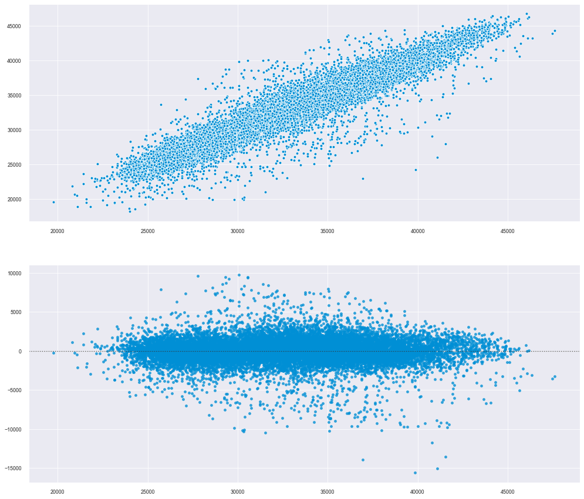

```python
fig,ax=plt.subplots(nrows=2,figsize=(15,15))
preds=model_second.predict(df_second)
sns.scatterplot(x=preds,y=label_sec,ax=ax[0])
sns.residplot(preds, label_sec,ax=ax[1])
```

```python
print(mean_absolute_error(preds,label_sec))
print(mean_squared_error(preds,label_sec))
```

```
1117.3316119869576
2683127.276219134
```

# 5. Catboost

First data

```python
df_first_cat.drop(columns=["previous_T_3","previous_T_4","previous_T_5","previous_T_6","previous_T_7"],inplace=True)
```

```python
from catboost import CatBoostRegressor

X_train,X_valid,y_train,y_valid=train_test_split(df_first_cat.drop("Consumption",axis=1),df_first_cat["Consumption"],test_size=0.2)

model_cf = CatBoostRegressor(learning_rate=0.1,num_boost_round=1000,objective="RMSE",early_stopping_rounds=100,
                          #task_type="GPU",
                          random_state=1337,
                          depth=12,
                          #bootstrap_type="Poisson",
                          subsample=0.95,
                          max_bin=150)

eval_set=[(X_valid,y_valid)]

model_cf.fit(X_train,y_train,
          eval_set=eval_set,
          cat_features=[X_train.columns.tolist().index(i) for i in categoric_vars],verbose=2)
```

```
0:	learn: 4421.0068756	test: 4432.6501493	best: 4432.6501493 (0)	total: 85.5ms	remaining: 1m 25s
2:	learn: 3788.9618979	test: 3795.0090952	best: 3795.0090952 (2)	total: 198ms	remaining: 1m 5s
4:	learn: 3298.8160094	test: 3303.1095510	best: 3303.1095510 (4)	total: 371ms	remaining: 1m 13s
6:	learn: 2904.8488760	test: 2912.2439836	best: 2912.2439836 (6)	total: 537ms	remaining: 1m 16s
8:	learn: 2596.9774929	test: 2599.1396883	best: 2599.1396883 (8)	total: 683ms	remaining: 1m 15s
10:	learn: 2353.7646594	test: 2352.3623156	best: 2352.3623156 (10)	total: 831ms	remaining: 1m 14s
12:	learn: 2159.0718763	test: 2156.4304995	best: 2156.4304995 (12)	total: 979ms	remaining: 1m 14s
14:	learn: 2011.3851333	test: 2014.0901571	best: 2014.0901571 (14)	total: 1.15s	remaining: 1m 15s
16:	learn: 1895.3519149	test: 1904.8431644	best: 1904.8431644 (16)	total: 1.3s	remaining: 1m 15s
18:	learn: 1799.6781336	test: 1813.3968236	best: 1813.3968236 (18)	total: 1.45s	remaining: 1m 14s
20:	learn: 1675.8696071	test: 1678.4875883	best: 1678.4875883 (20)	total: 1.6s	remaining: 1m 14s
22:	learn: 1568.3287815	test: 1563.5319703	best: 1563.5319703 (22)	total: 1.77s	remaining: 1m 15s
24:	learn: 1475.9102229	test: 1465.6339363	best: 1465.6339363 (24)	total: 1.93s	remaining: 1m 15s
26:	learn: 1407.1456902	test: 1395.5041111	best: 1395.5041111 (26)	total: 2.08s	remaining: 1m 15s
28:	learn: 1346.5148166	test: 1332.9327544	best: 1332.9327544 (28)	total: 2.24s	remaining: 1m 15s
30:	learn: 1290.6315451	test: 1281.8645601	best: 1281.8645601 (30)	total: 2.4s	remaining: 1m 14s
32:	learn: 1258.1479501	test: 1250.4080284	best: 1250.4080284 (32)	total: 2.49s	remaining: 1m 13s
34:	learn: 1212.5825040	test: 1211.1510922	best: 1211.1510922 (34)	total: 2.68s	remaining: 1m 13s
36:	learn: 1173.6690913	test: 1170.0533503	best: 1170.0533503 (36)	total: 2.85s	remaining: 1m 14s
38:	learn: 1149.8013869	test: 1146.4583532	best: 1146.4583532 (38)	total: 2.96s	remaining: 1m 12s
40:	learn: 1130.2806462	test: 1125.8779000	best: 1125.8779000 (40)	total: 3.04s	remaining: 1m 11s
42:	learn: 1114.6736670	test: 1109.5156245	best: 1109.5156245 (42)	total: 3.15s	remaining: 1m 10s
44:	learn: 1088.8438488	test: 1086.8339592	best: 1086.8339592 (44)	total: 3.32s	remaining: 1m 10s
46:	learn: 1060.2023302	test: 1061.2322930	best: 1061.2322930 (46)	total: 3.5s	remaining: 1m 10s
48:	learn: 1034.0224794	test: 1040.3714919	best: 1040.3714919 (48)	total: 3.64s	remaining: 1m 10s
50:	learn: 1022.5920630	test: 1029.5947835	best: 1029.5947835 (50)	total: 3.73s	remaining: 1m 9s
52:	learn: 996.2896086	test: 1009.9073767	best: 1009.9073767 (52)	total: 3.9s	remaining: 1m 9s
54:	learn: 976.8309369	test: 992.6629744	best: 992.6629744 (54)	total: 4.06s	remaining: 1m 9s
56:	learn: 956.7421168	test: 973.3717267	best: 973.3717267 (56)	total: 4.21s	remaining: 1m 9s
58:	learn: 939.0293556	test: 958.6772364	best: 958.6772364 (58)	total: 4.36s	remaining: 1m 9s
60:	learn: 931.3245229	test: 952.9609233	best: 952.9609233 (60)	total: 4.44s	remaining: 1m 8s
62:	learn: 916.0186822	test: 938.4120917	best: 938.4120917 (62)	total: 4.58s	remaining: 1m 8s
64:	learn: 908.1810335	test: 931.8632871	best: 931.8632871 (64)	total: 4.67s	remaining: 1m 7s
66:	learn: 894.7619049	test: 922.0004253	best: 922.0004253 (66)	total: 4.81s	remaining: 1m 6s
68:	learn: 885.2592695	test: 915.2778596	best: 915.2778596 (68)	total: 4.96s	remaining: 1m 6s
70:	learn: 874.6863737	test: 907.1712565	best: 907.1712565 (70)	total: 5.11s	remaining: 1m 6s
72:	learn: 866.2019648	test: 898.8657596	best: 898.8657596 (72)	total: 5.26s	remaining: 1m 6s
74:	learn: 860.7580414	test: 893.6206381	best: 893.6206381 (74)	total: 5.36s	remaining: 1m 6s
76:	learn: 849.2690545	test: 884.2647536	best: 884.2647536 (76)	total: 5.52s	remaining: 1m 6s
78:	learn: 842.4884519	test: 880.1383970	best: 880.1383970 (78)	total: 5.67s	remaining: 1m 6s
```

[output cut: 451 more lines]

```
982:	learn: 68.7746457	test: 537.1091446	best: 537.0983825 (981)	total: 1m 16s	remaining: 1.32s
984:	learn: 68.4954709	test: 537.1013036	best: 537.0983825 (981)	total: 1m 16s	remaining: 1.17s
986:	learn: 68.1933395	test: 537.0172600	best: 537.0172600 (986)	total: 1m 16s	remaining: 1.01s
988:	learn: 67.8744395	test: 536.9650434	best: 536.9650434 (988)	total: 1m 16s	remaining: 855ms
990:	learn: 67.6152647	test: 536.9429451	best: 536.9429451 (990)	total: 1m 17s	remaining: 700ms
992:	learn: 67.4244940	test: 536.9161776	best: 536.9161776 (992)	total: 1m 17s	remaining: 544ms
994:	learn: 67.2246542	test: 536.8883193	best: 536.8883193 (994)	total: 1m 17s	remaining: 389ms
996:	learn: 67.0703938	test: 536.8619356	best: 536.8619356 (996)	total: 1m 17s	remaining: 233ms
998:	learn: 66.9444727	test: 536.8580626	best: 536.8530088 (997)	total: 1m 17s	remaining: 77.7ms
999:	learn: 66.8360741	test: 536.8594729	best: 536.8530088 (997)	total: 1m 17s	remaining: 0us

bestTest = 536.8530088
bestIteration = 997

Shrink model to first 998 iterations.
```

```
<catboost.core.CatBoostRegressor at 0x1a465d4650>
```

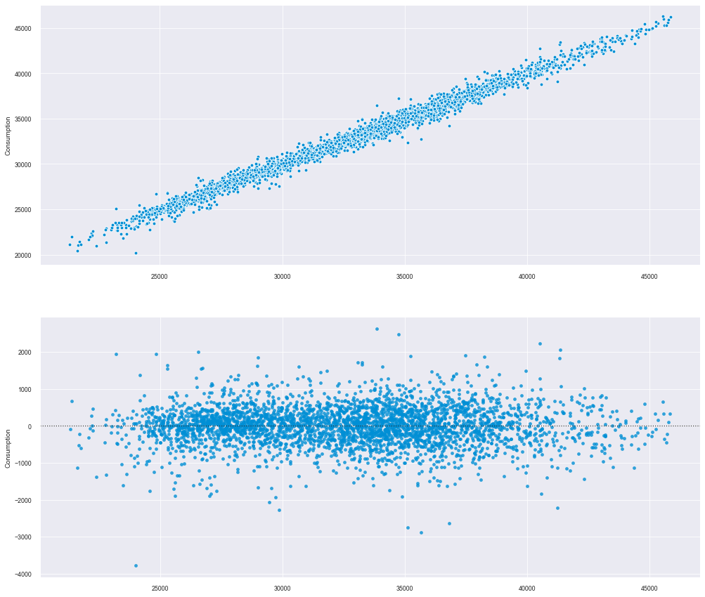

```python
fig,ax=plt.subplots(nrows=2,figsize=(15,15))
preds=model_cf.predict(X_valid)
sns.scatterplot(x=preds,y=y_valid,ax=ax[0])
sns.residplot(preds, y_valid,ax=ax[1])
```